# Risk Factor Analysis

## Outcome Variable

**Outcome Variable:** swasted

## Predictor Variables

**Intervention Variable:** hdlvry

**Adjustment Set:**

- arm
- sex
- W_mage
- meducyrs
- feducyrs
- hhwealth_quart
- single
- W_nrooms
- brthmon
- W_parity
- impsan
- delta_W_mage
- delta_meducyrs
- delta_feducyrs
- delta_hhwealth_quart
- delta_single
- delta_W_nrooms
- delta_brthmon
- delta_W_parity
- delta_impsan

## Stratifying Variables

The analysis was stratified on these variable(s):

- agecat
- studyid
- country

## Data Summary

| agecat | studyid | country | hdlvry | swasted | n_cell | n |
| --- | --- | --- | --- | --- | --- | --- |
| Birth | CMC-V-BCS-2002 | INDIA | 0 | 0 | 85 | 86 |
| Birth | CMC-V-BCS-2002 | INDIA | 0 | 1 | 1 | 86 |
| Birth | CMC-V-BCS-2002 | INDIA | 1 | 0 | 0 | 86 |
| Birth | CMC-V-BCS-2002 | INDIA | 1 | 1 | 0 | 86 |
| Birth | COHORTS | INDIA | 0 | 0 | 2642 | 4389 |
| Birth | COHORTS | INDIA | 0 | 1 | 121 | 4389 |
| Birth | COHORTS | INDIA | 1 | 0 | 1539 | 4389 |
| Birth | COHORTS | INDIA | 1 | 1 | 87 | 4389 |
| Birth | EE | PAKISTAN | 0 | 0 | 117 | 175 |
| Birth | EE | PAKISTAN | 0 | 1 | 3 | 175 |
| Birth | EE | PAKISTAN | 1 | 0 | 52 | 175 |
| Birth | EE | PAKISTAN | 1 | 1 | 3 | 175 |
| Birth | GMS-Nepal | NEPAL | 0 | 0 | 135 | 596 |
| Birth | GMS-Nepal | NEPAL | 0 | 1 | 8 | 596 |
| Birth | GMS-Nepal | NEPAL | 1 | 0 | 437 | 596 |
| Birth | GMS-Nepal | NEPAL | 1 | 1 | 16 | 596 |
| Birth | IRC | INDIA | 0 | 0 | 285 | 343 |
| Birth | IRC | INDIA | 0 | 1 | 52 | 343 |
| Birth | IRC | INDIA | 1 | 0 | 4 | 343 |
| Birth | IRC | INDIA | 1 | 1 | 2 | 343 |
| Birth | JiVitA-3 | BANGLADESH | 0 | 0 | 27 | 292 |
| Birth | JiVitA-3 | BANGLADESH | 0 | 1 | 0 | 292 |
| Birth | JiVitA-3 | BANGLADESH | 1 | 0 | 263 | 292 |
| Birth | JiVitA-3 | BANGLADESH | 1 | 1 | 2 | 292 |
| Birth | JiVitA-4 | BANGLADESH | 0 | 0 | 494 | 2384 |
| Birth | JiVitA-4 | BANGLADESH | 0 | 1 | 6 | 2384 |
| Birth | JiVitA-4 | BANGLADESH | 1 | 0 | 1859 | 2384 |
| Birth | JiVitA-4 | BANGLADESH | 1 | 1 | 25 | 2384 |
| Birth | NIH-Crypto | BANGLADESH | 0 | 0 | 515 | 707 |
| Birth | NIH-Crypto | BANGLADESH | 0 | 1 | 33 | 707 |

[output cut: 98 more lines]

The following strata were considered:

- agecat: 24 months, studyid: CMC-V-BCS-2002, country: INDIA
- agecat: 24 months, studyid: COHORTS, country: INDIA
- agecat: 24 months, studyid: EE, country: PAKISTAN
- agecat: 24 months, studyid: GMS-Nepal, country: NEPAL
- agecat: 24 months, studyid: IRC, country: INDIA
- agecat: 24 months, studyid: JiVitA-3, country: BANGLADESH
- agecat: 24 months, studyid: JiVitA-4, country: BANGLADESH
- agecat: 24 months, studyid: NIH-Crypto, country: BANGLADESH
- agecat: 24 months, studyid: PROVIDE, country: BANGLADESH
- agecat: 24 months, studyid: TanzaniaChild2, country: TANZANIA, UNITED REPUBLIC OF
- agecat: 6 months, studyid: CMC-V-BCS-2002, country: INDIA
- agecat: 6 months, studyid: COHORTS, country: INDIA
- agecat: 6 months, studyid: EE, country: PAKISTAN
- agecat: 6 months, studyid: GMS-Nepal, country: NEPAL
- agecat: 6 months, studyid: IRC, country: INDIA
- agecat: 6 months, studyid: JiVitA-3, country: BANGLADESH
- agecat: 6 months, studyid: JiVitA-4, country: BANGLADESH
- agecat: 6 months, studyid: NIH-Crypto, country: BANGLADESH
- agecat: 6 months, studyid: PROVIDE, country: BANGLADESH
- agecat: 6 months, studyid: SAS-CompFeed, country: INDIA
- agecat: 6 months, studyid: SAS-FoodSuppl, country: INDIA
- agecat: 6 months, studyid: TanzaniaChild2, country: TANZANIA, UNITED REPUBLIC OF
- agecat: Birth, studyid: CMC-V-BCS-2002, country: INDIA
- agecat: Birth, studyid: COHORTS, country: INDIA
- agecat: Birth, studyid: EE, country: PAKISTAN
- agecat: Birth, studyid: GMS-Nepal, country: NEPAL
- agecat: Birth, studyid: IRC, country: INDIA
- agecat: Birth, studyid: JiVitA-3, country: BANGLADESH
- agecat: Birth, studyid: JiVitA-4, country: BANGLADESH
- agecat: Birth, studyid: NIH-Crypto, country: BANGLADESH
- agecat: Birth, studyid: PROVIDE, country: BANGLADESH
- agecat: Birth, studyid: SAS-CompFeed, country: INDIA

### Dropped Strata

Some strata were dropped due to rare outcomes:

- agecat: Birth, studyid: CMC-V-BCS-2002, country: INDIA
- agecat: Birth, studyid: EE, country: PAKISTAN
- agecat: Birth, studyid: IRC, country: INDIA
- agecat: Birth, studyid: JiVitA-3, country: BANGLADESH
- agecat: Birth, studyid: PROVIDE, country: BANGLADESH
- agecat: Birth, studyid: SAS-CompFeed, country: INDIA
- agecat: 6 months, studyid: CMC-V-BCS-2002, country: INDIA
- agecat: 6 months, studyid: EE, country: PAKISTAN
- agecat: 6 months, studyid: GMS-Nepal, country: NEPAL
- agecat: 6 months, studyid: IRC, country: INDIA
- agecat: 6 months, studyid: JiVitA-3, country: BANGLADESH
- agecat: 6 months, studyid: NIH-Crypto, country: BANGLADESH
- agecat: 6 months, studyid: PROVIDE, country: BANGLADESH
- agecat: 6 months, studyid: SAS-CompFeed, country: INDIA
- agecat: 6 months, studyid: SAS-FoodSuppl, country: INDIA
- agecat: 6 months, studyid: TanzaniaChild2, country: TANZANIA, UNITED REPUBLIC OF
- agecat: 24 months, studyid: CMC-V-BCS-2002, country: INDIA
- agecat: 24 months, studyid: EE, country: PAKISTAN
- agecat: 24 months, studyid: GMS-Nepal, country: NEPAL
- agecat: 24 months, studyid: IRC, country: INDIA
- agecat: 24 months, studyid: JiVitA-3, country: BANGLADESH
- agecat: 24 months, studyid: NIH-Crypto, country: BANGLADESH
- agecat: 24 months, studyid: PROVIDE, country: BANGLADESH
- agecat: 24 months, studyid: TanzaniaChild2, country: TANZANIA, UNITED REPUBLIC OF

## Methods Detail

We’re interested in the causal parameters $E[Y_a]$ for all values of $a \in \mathcal{A}$. These parameters represent the mean outcome if, possibly contrary to fact, we intervened to set all units to have $A=a$. Under the randomization and positivity assumptions, these are identified by the statistical parameters $\psi_a=E_W[E_{Y|A,W}(Y|A=a,W)]$. In addition, we’re interested in the mean of $Y$, $E[Y]$ under no intervention (the observed mean). We will estimate these parameters by using SuperLearner to fit the relevant likelihood factors – $E_{Y|A,W}(Y|A=a,W)$ and $p(A=a|W)$, and then updating our likelihood fit using a joint TMLE.

For unadjusted analyses ($W=\{\}$), initial likelihoods were estimated using Lrnr_glm to estimate the simple $E(Y|A)$ and Lrnr_mean to estimate $p(A)$. For adjusted analyses, a small library containing Lrnr_glmnet, Lrnr_xgboost, and Lrnr_mean was used.

Having estimated these parameters, we will then use the delta method to estimate relative risks and attributable risks relative to a prespecified baseline level of $A$.

# Results Detail

## Results Plots

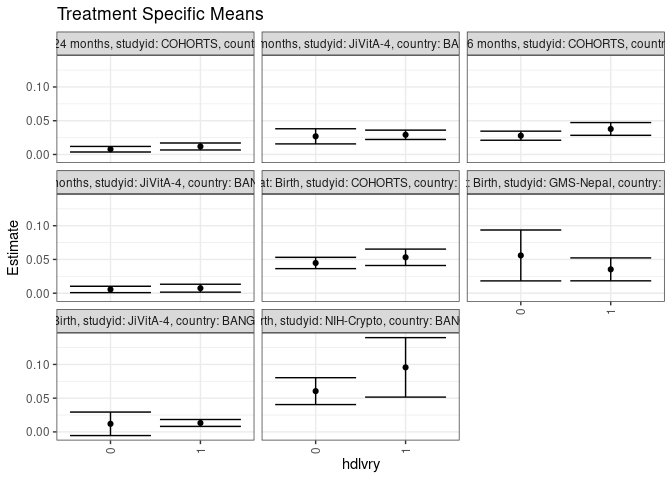

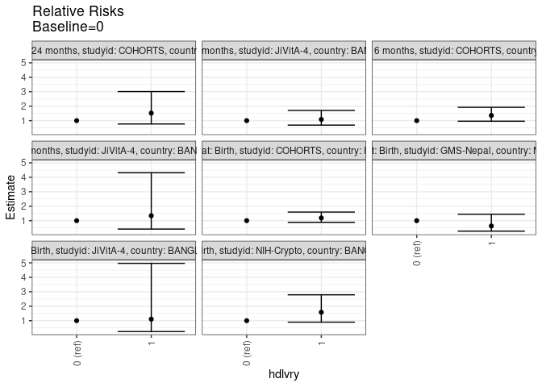

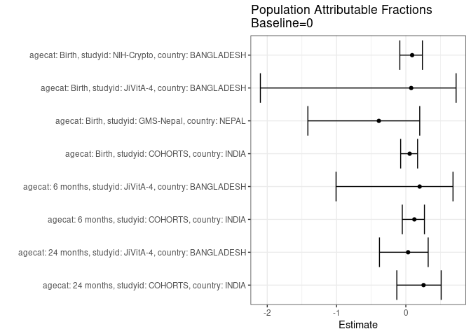

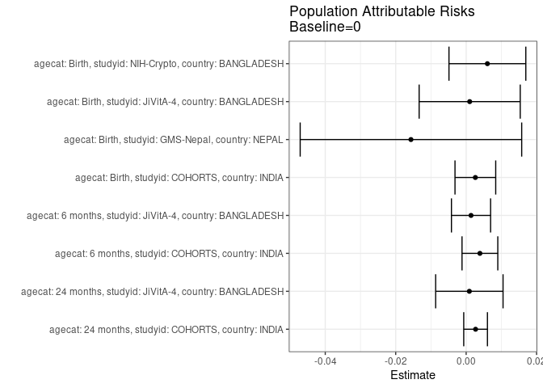

## Results Table

### Parameter: TSM

| agecat | studyid | country | intervention_level | baseline_level | estimate | ci_lower | ci_upper |
| --- | --- | --- | --- | --- | --- | --- | --- |
| Birth | COHORTS | INDIA | 0 | NA | 0.0447783 | 0.0364110 | 0.0531457 |
| Birth | COHORTS | INDIA | 1 | NA | 0.0531834 | 0.0410528 | 0.0653139 |
| Birth | GMS-Nepal | NEPAL | 0 | NA | 0.0559441 | 0.0182459 | 0.0936423 |
| Birth | GMS-Nepal | NEPAL | 1 | NA | 0.0353201 | 0.0183077 | 0.0523325 |
| Birth | JiVitA-4 | BANGLADESH | 0 | NA | 0.0120000 | -0.0054099 | 0.0294099 |
| Birth | JiVitA-4 | BANGLADESH | 1 | NA | 0.0132696 | 0.0081641 | 0.0183752 |
| Birth | NIH-Crypto | BANGLADESH | 0 | NA | 0.0604477 | 0.0405291 | 0.0803663 |
| Birth | NIH-Crypto | BANGLADESH | 1 | NA | 0.0956532 | 0.0516109 | 0.1396955 |
| 6 months | COHORTS | INDIA | 0 | NA | 0.0278373 | 0.0211219 | 0.0345526 |
| 6 months | COHORTS | INDIA | 1 | NA | 0.0378177 | 0.0283581 | 0.0472772 |
| 6 months | JiVitA-4 | BANGLADESH | 0 | NA | 0.0055453 | 0.0008107 | 0.0102799 |
| 6 months | JiVitA-4 | BANGLADESH | 1 | NA | 0.0074324 | 0.0015459 | 0.0133190 |
| 24 months | COHORTS | INDIA | 0 | NA | 0.0077941 | 0.0036847 | 0.0119035 |
| 24 months | COHORTS | INDIA | 1 | NA | 0.0118572 | 0.0066992 | 0.0170152 |
| 24 months | JiVitA-4 | BANGLADESH | 0 | NA | 0.0268901 | 0.0156960 | 0.0380841 |
| 24 months | JiVitA-4 | BANGLADESH | 1 | NA | 0.0291702 | 0.0222553 | 0.0360850 |

### Parameter: E(Y)

| agecat | studyid | country | intervention_level | baseline_level | estimate | ci_lower | ci_upper |
| --- | --- | --- | --- | --- | --- | --- | --- |
| Birth | COHORTS | INDIA | NA | NA | 0.0473912 | 0.0411045 | 0.0536779 |
| Birth | GMS-Nepal | NEPAL | NA | NA | 0.0402685 | 0.0244725 | 0.0560645 |
| Birth | JiVitA-4 | BANGLADESH | NA | NA | 0.0130034 | 0.0075709 | 0.0184358 |
| Birth | NIH-Crypto | BANGLADESH | NA | NA | 0.0664781 | 0.0481022 | 0.0848539 |
| 6 months | COHORTS | INDIA | NA | NA | 0.0317427 | 0.0267269 | 0.0367584 |
| 6 months | JiVitA-4 | BANGLADESH | NA | NA | 0.0069273 | 0.0024440 | 0.0114105 |
| 24 months | COHORTS | INDIA | NA | NA | 0.0104727 | 0.0071155 | 0.0138299 |
| 24 months | JiVitA-4 | BANGLADESH | NA | NA | 0.0277986 | 0.0219343 | 0.0336630 |

### Parameter: RR

| agecat | studyid | country | intervention_level | baseline_level | estimate | ci_lower | ci_upper |
| --- | --- | --- | --- | --- | --- | --- | --- |
| Birth | COHORTS | INDIA | 0 | 0 | 1.0000000 | 1.0000000 | 1.000000 |
| Birth | COHORTS | INDIA | 1 | 0 | 1.1877029 | 0.8846963 | 1.594489 |
| Birth | GMS-Nepal | NEPAL | 0 | 0 | 1.0000000 | 1.0000000 | 1.000000 |
| Birth | GMS-Nepal | NEPAL | 1 | 0 | 0.6313466 | 0.2757666 | 1.445420 |
| Birth | JiVitA-4 | BANGLADESH | 0 | 0 | 1.0000000 | 1.0000000 | 1.000000 |
| Birth | JiVitA-4 | BANGLADESH | 1 | 0 | 1.1058033 | 0.2462205 | 4.966284 |
| Birth | NIH-Crypto | BANGLADESH | 0 | 0 | 1.0000000 | 1.0000000 | 1.000000 |
| Birth | NIH-Crypto | BANGLADESH | 1 | 0 | 1.5824125 | 0.8976832 | 2.789436 |
| 6 months | COHORTS | INDIA | 0 | 0 | 1.0000000 | 1.0000000 | 1.000000 |
| 6 months | COHORTS | INDIA | 1 | 0 | 1.3585254 | 0.9598251 | 1.922841 |
| 6 months | JiVitA-4 | BANGLADESH | 0 | 0 | 1.0000000 | 1.0000000 | 1.000000 |
| 6 months | JiVitA-4 | BANGLADESH | 1 | 0 | 1.3403153 | 0.4160078 | 4.318297 |
| 24 months | COHORTS | INDIA | 0 | 0 | 1.0000000 | 1.0000000 | 1.000000 |
| 24 months | COHORTS | INDIA | 1 | 0 | 1.5213009 | 0.7684152 | 3.011856 |
| 24 months | JiVitA-4 | BANGLADESH | 0 | 0 | 1.0000000 | 1.0000000 | 1.000000 |
| 24 months | JiVitA-4 | BANGLADESH | 1 | 0 | 1.0847926 | 0.6894112 | 1.706927 |

### Parameter: PAR

| agecat | studyid | country | intervention_level | baseline_level | estimate | ci_lower | ci_upper |
| --- | --- | --- | --- | --- | --- | --- | --- |
| Birth | COHORTS | INDIA | 0 | NA | 0.0026129 | -0.0031666 | 0.0083924 |
| Birth | GMS-Nepal | NEPAL | 0 | NA | -0.0156756 | -0.0471193 | 0.0157681 |
| Birth | JiVitA-4 | BANGLADESH | 0 | NA | 0.0010034 | -0.0133484 | 0.0153551 |
| Birth | NIH-Crypto | BANGLADESH | 0 | NA | 0.0060304 | -0.0048771 | 0.0169378 |
| 6 months | COHORTS | INDIA | 0 | NA | 0.0039054 | -0.0011738 | 0.0089845 |
| 6 months | JiVitA-4 | BANGLADESH | 0 | NA | 0.0013820 | -0.0041754 | 0.0069393 |
| 24 months | COHORTS | INDIA | 0 | NA | 0.0026786 | -0.0006862 | 0.0060434 |
| 24 months | JiVitA-4 | BANGLADESH | 0 | NA | 0.0009086 | -0.0086573 | 0.0104744 |

### Parameter: PAF

| agecat | studyid | country | intervention_level | baseline_level | estimate | ci_lower | ci_upper |
| --- | --- | --- | --- | --- | --- | --- | --- |
| Birth | COHORTS | INDIA | 0 | NA | 0.0551340 | -0.0749549 | 0.1694799 |
| Birth | GMS-Nepal | NEPAL | 0 | NA | -0.3892774 | -1.4139478 | 0.2004418 |
| Birth | JiVitA-4 | BANGLADESH | 0 | NA | 0.0771613 | -2.0994742 | 0.7252336 |
| Birth | NIH-Crypto | BANGLADESH | 0 | NA | 0.0907120 | -0.0868971 | 0.2392981 |
| 6 months | COHORTS | INDIA | 0 | NA | 0.1230323 | -0.0512363 | 0.2684116 |
| 6 months | JiVitA-4 | BANGLADESH | 0 | NA | 0.1994983 | -1.0071943 | 0.6807469 |
| 24 months | COHORTS | INDIA | 0 | NA | 0.2557681 | -0.1301126 | 0.5098885 |
| 24 months | JiVitA-4 | BANGLADESH | 0 | NA | 0.0326842 | -0.3806344 | 0.3222681 |